# Assignment Operators in R

2024

## Assignment Operators in R

### Overview

- R provides two operators for assignment: `<-` and `=`.
- Understanding their proper use is crucial for writing clear and readable R code.

## Using the `<-` Operator

### For Assignments

- The `<-` operator is the preferred choice for assigning values to variables in R.
- It clearly distinguishes assignment from argument specification in function calls.

```r
# Correct usage of <- for assignment
x <- 10

# Correct usage of <- for assignment in a list and the =
# operator for specifying named arguments
my_list <- list(a = 1, b = 2)
```

### Readability and Tradition

- This usage aligns with R’s tradition and enhances code readability.

## Using the `=` Operator

- The `=` operator is commonly used to explicitly specify named arguments in function calls.
- It helps in distinguishing argument assignment from variable assignment.

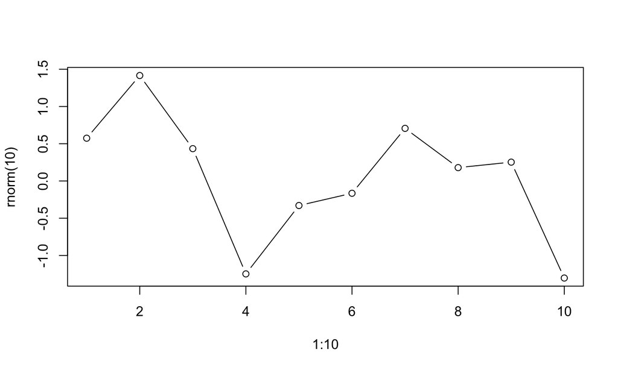

```r
# Correct usage of = for specifying function arguments
plot(x = 1:10, y = rnorm(10), type = "b")
```

### Assignment Capability

- While `=` can also be used for assignment, this practice is less common and not recommended for clarity.

```r
# Less recommended usage of = for assignment
x = 10  # Works, but not preferred
```

## Mixing Up Operators

### Potential Confusion

- Using `=` for general assignments can lead to confusion, especially when reading or debugging code.
- Mixing operators inconsistently can obscure the distinction between assignment and function argument specification.

### Examples

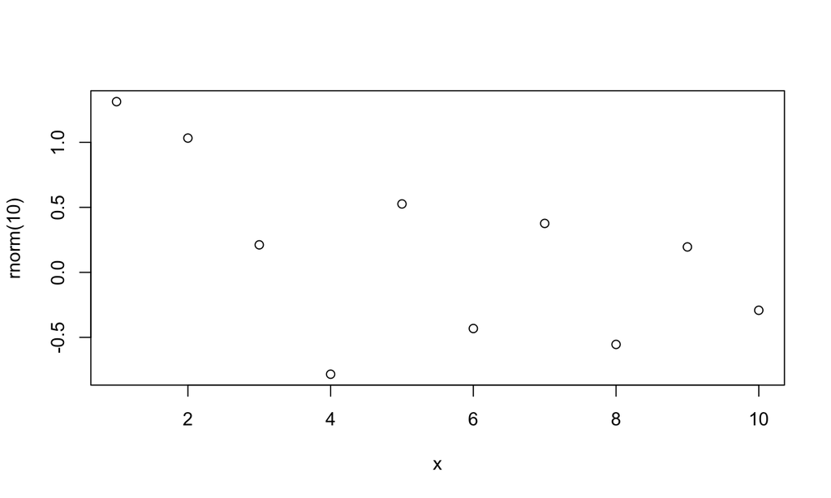

```r
# Potentially confusing usage
x = seq(1, 10)  # Assignment
plot(x = x, y = rnorm(10))  # Argument specification
```

## Best Practices Recap

### Consistency and Clarity

- Use `<-` for variable assignments to maintain consistency and clarity.
- Reserve `=` for specifying named arguments in function calls.

### Avoiding Common Mistakes

- Be mindful of the context in which you use each operator to prevent misunderstandings.
- Consistently using the operators as recommended helps make your code more readable and maintainable.

## Quiz: Assignment Operator Best Practices

Which of the following examples demonstrates the recommended use of assignment operators in R?

1. `my_var = 5; mean(x = my_var)`
2. `my_var <- 5; mean(x <- my_var)`
3. `my_var <- 5; mean(x = my_var)`
4. `my_var = 5; mean(x <- my_var)`

### Answer

**Click here for the answer**

- The correct answer is **3**. `my_var <- 5; mean(x = my_var)` correctly uses `<-` for variable assignment and `=` for specifying a named argument in a function call.